# Appendix A — Appendix A: Hypersphere Point Placement Algorithm

- Show All Code
- Hide All Code
- View Source

## A.1 Algorithm Description

The hypersphere point placement scheme generates $m$ sample points distributed approximately uniformly on the surface of an $n$-dimensional unit hypersphere, then maps them into the interior of the unit hypercube. The algorithm exploits the well-known result that normalised Gaussian random vectors are uniformly distributed on the unit sphere.

### A.1.1 Step-by-Step Algorithm

1. **Generate** $m$ vectors $\mathbf{u}_i \in \mathbb{R}^n$, each drawn from an $n$-dimensional standard Gaussian distribution:
   $$\mathbf{u}_i \sim \mathcal{N}(0, I_n)$$
2. **Normalise** each vector to unit length (project to sphere surface):
   $$\hat{\mathbf{u}}_i = \frac{\mathbf{u}_i}{\|\mathbf{u}_i\|}$$
3. **Map** from $[-1, 1]^n$ (sphere surface coordinates) to $[0, 1]^n$:
   $$\mathbf{x}_i = \frac{\hat{\mathbf{u}}_i + \mathbf{1}}{2}$$

### A.1.2 Anti-Bunching Property

For large $n$, the hypercube has most of its volume concentrated in the corners. Uniform random points in a hypercube tend to cluster in corners, leaving the interior sparsely sampled. The hypersphere scheme avoids this by ensuring points lie on a surface of equal radial distance from the origin — a strong anti-bunching mechanism that produces more even coverage of the design space.

The 2002 paper defines the inter-point Euclidean distance in Appendix A, Eq. A2:

$$d(\mathbf{X}_A, \mathbf{X}_B) = \sqrt{\sum_{i=1}^{n} (X_{A_i} - X_{B_i})^2}
\tag{A.1}$$

**Important2002 Paper Errata — Eq. A2**

NASA/CR-2002-211652, Appendix A, Eq. A2 omits the square on the difference term. The printed equation reads $\sqrt{\sum (X_{A_i} - X_{B_i})}$, which is dimensionally inconsistent and would not produce a proper Euclidean distance. The correct form is $\sqrt{\sum (X_{A_i} - X_{B_i})^2}$ as shown in Equation A.1 above. This is a typographical error only — the Julia implementation uses the correct formula. See Appendix C for the full errata list.

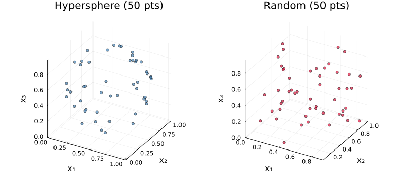

```julia
rng = MersenneTwister(42)
pts_hs = hypersphere_points(3, 50; seed=42)
pts_rn = random_points(3, 50; seed=42)

p1 = scatter3d(pts_hs[:,1], pts_hs[:,2], pts_hs[:,3],
               xlabel="x₁", ylabel="x₂", zlabel="x₃",
               title="Hypersphere (50 pts)", markersize=3,
               color=:steelblue, alpha=0.7, legend=false)

p2 = scatter3d(pts_rn[:,1], pts_rn[:,2], pts_rn[:,3],
               xlabel="x₁", ylabel="x₂", zlabel="x₃",
               title="Random (50 pts)", markersize=3,
               color=:crimson, alpha=0.7, legend=false)

plot(p1, p2, size=(800, 380))
```

## A.2 Minimum Point Count

A key advantage of the hypersphere scheme is that the number of points is determined solely by the minimum required for the RS model ($N_S$ from Equation 6.9), not by the formula of any specific classical design. This gives the designer freedom to generate exactly as many points as needed.

```julia
# For each dimensionality, show the minimum required and a recommended augmented count
println("n | NS_min | Recommended (NS_min + 10%)")
println("-" ^ 42)
for n in 2:12
    ns_min = min_rs_points(n)
    ns_rec = ceil(Int, 1.1 * ns_min)
    @printf("%2d | %6d | %25d\n", n, ns_min, ns_rec)
end
```

```
n | NS_min | Recommended (NS_min + 10%)
------------------------------------------
 2 |      6 |                         7
 3 |     10 |                        11
 4 |     15 |                        17
 5 |     21 |                        24
 6 |     28 |                        31
 7 |     36 |                        40
 8 |     45 |                        50
 9 |     55 |                        61
10 |     66 |                        73
11 |     78 |                        86
12 |     91 |                       101
```

## A.3 Julia Implementation (Full Detail)

```julia
function hypersphere_points_full(n::Int, m::Int; seed::Int=42) :: Matrix{Float64}
    # Step 1: n-dimensional Gaussian samples
    rng  = MersenneTwister(seed)
    U    = randn(rng, m, n)             # m × n matrix of raw Gaussian samples

    # Step 2: normalise each row to unit Euclidean norm
    norms = sqrt.(sum(U .^ 2, dims=2))  # m × 1 column of norms
    U_hat = U ./ norms                  # each row now has norm = 1

    # Step 3: map from [-1,1]ⁿ to [0,1]ⁿ
    X = (U_hat .+ 1.0) ./ 2.0

    return X
end

# Verify the implementation matches src/bliss_rs.jl
pts_ref  = hypersphere_points(3, 20; seed=99)
pts_full = hypersphere_points_full(3, 20; seed=99)
@printf("Max discrepancy vs. reference: %.2e\n", maximum(abs.(pts_ref .- pts_full)))
```

```
Max discrepancy vs. reference: 0.00e+00
```

## A.4 Comparison with Classical Designs in 2D

[figure not shown]

```julia
# Central Composite Design (2 factors, α = √2 for rotatable)
α = sqrt(2.0)
cube_pts = [[-1,-1],[1,-1],[-1,1],[1,1]]
axial_pts = [[-α,0],[α,0],[0,-α],[0,α]]
center_pt = [[0.0,0.0],[0,0],[0,0]]
ccd_pts = vcat(cube_pts, axial_pts, center_pt)
ccd_mat = hcat([[p[1] for p in ccd_pts], [p[2] for p in ccd_pts]]...)'
ccd_mat = (ccd_mat .+ α) ./ (2α)   # scale to [0,1]

# Other designs
hs_pts   = hypersphere_points(2, 15; seed=42)
dopt_pts = d_optimal_points(2, 15; seed=42)
rnd_pts  = random_points(2, 15; seed=42)

scatter_kw = (xlim=(-0.05,1.05), ylim=(-0.05,1.05),
              aspect_ratio=1, legend=false, grid=true, gridalpha=0.3,
              xlabel=L"x_1", ylabel=L"x_2")

p1 = scatter(ccd_mat[:,1], ccd_mat[:,2]; title="CCD (11 pts)",
             markersize=7, color=:darkorange, markerstrokecolor=:white, scatter_kw...)
p2 = scatter(hs_pts[:,1], hs_pts[:,2]; title="Hypersphere (15 pts)",
             markersize=7, color=:steelblue, markerstrokecolor=:white, scatter_kw...)
p3 = scatter(dopt_pts[:,1], dopt_pts[:,2]; title="D-Optimal (15 pts)",
             markersize=7, color=:forestgreen, markerstrokecolor=:white, scatter_kw...)
p4 = scatter(rnd_pts[:,1], rnd_pts[:,2]; title="Random (15 pts)",
             markersize=7, color=:crimson, markerstrokecolor=:white, scatter_kw...)

plot(p1, p2, p3, p4, layout=(2,2), size=(680, 580))
```